# “Reproducible Research: Peer Assessment 1”

## Loading and preprocessing the data

Here we read in the datafile.

```r
dataFile <- read.csv("./activity/activity.csv",sep = ",",header = TRUE)
dataFile$date <- as_date(as.character(dataFile$date))
```

What is mean total number of steps taken per day?

```r
summarizedByDate <- group_by(dataFile, date)

dailySum <- summarize(summarizedByDate, sum.steps = sum(steps,na.rm = TRUE))
```

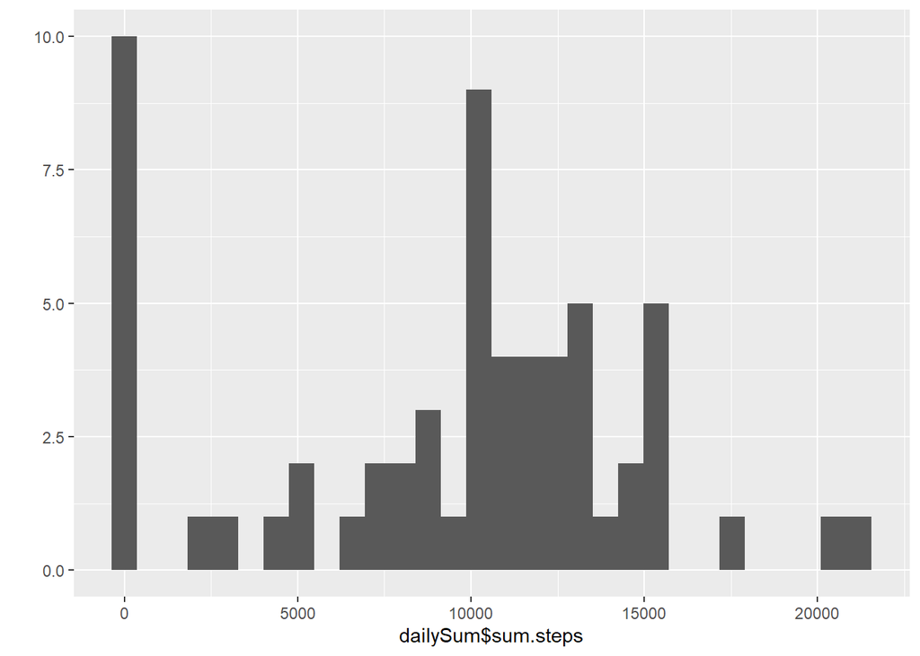

```r
qplot(dailySum$sum.steps)
```

```r
daily.mean <- mean(summarizedByDate$steps ,na.rm = TRUE)
daily.median <- median(summarizedByDate$steps,na.rm = TRUE)
```

## What is the average daily activity pattern?

Here we plot the average daily activity pattern.

```r
dailyAve <- summarize(summarizedByDate, ave.steps = mean(steps,na.rm = TRUE))
summarizedByInterval <- group_by(dataFile, interval)
dailyInterval <- summarize(summarizedByInterval, ave.steps = mean(steps,na.rm = T))
```

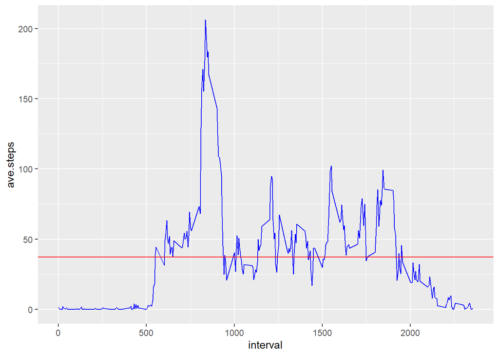

```r
intervalPlot <- ggplot(dailyInterval, aes(interval,ave.steps)) + geom_line(color="blue") + geom_hline(aes(yintercept = daily.mean),color="red")
print(intervalPlot)
```

This snippet plots the average steps each day over the 2 months, which I’m just keeping here for my own reference (not part of the assignment, and not meant to be used code).  
y <- ggplot(dailyAve, aes(date,ave.steps)) + geom_line(color=“blue”)  
y <- y + geom_hline(aes(yintercept = daily.mean),color=“red”)  
print(y)

## Largest average daily steps

This part finds the 5 minumte interval with the largest average daily steps which turns out to be interval #835 with 206 steps on average

```r
maxInterval <- which.max(dailyInterval$ave.steps)
dailyInterval[maxInterval,]
```

```
## # A tibble: 1 x 2
##   interval ave.steps
##      <int>     <dbl>
## 1      835      206.
```

## Imputing missing values

My strategy for replacing missing values is to use the 5-minute daily interval mean

```r
totalMissingData <- sum(is.na(dataFile$steps))

imputedDataFile <- dataFile
for (i in 1:nrow(dataFile)) {
  if (is.na(dataFile$steps[i]) == TRUE) {
    corrInterval <- dataFile$interval[i]
    corrIndexVal <- which(dailyInterval$interval == corrInterval)
    imputedDataFile$steps[i] <- dailyInterval$ave.steps[corrIndexVal]
  }
}

newMissingData <- sum(is.na(imputedDataFile$steps))
```

The total missing data was 2304 but now is 0.

## Historgram of total steps per day

```r
imputedSummarizedByDate <- group_by(imputedDataFile, date)

imputedDailySum <- summarize(imputedSummarizedByDate, sum.steps = sum(steps,na.rm = TRUE))
```

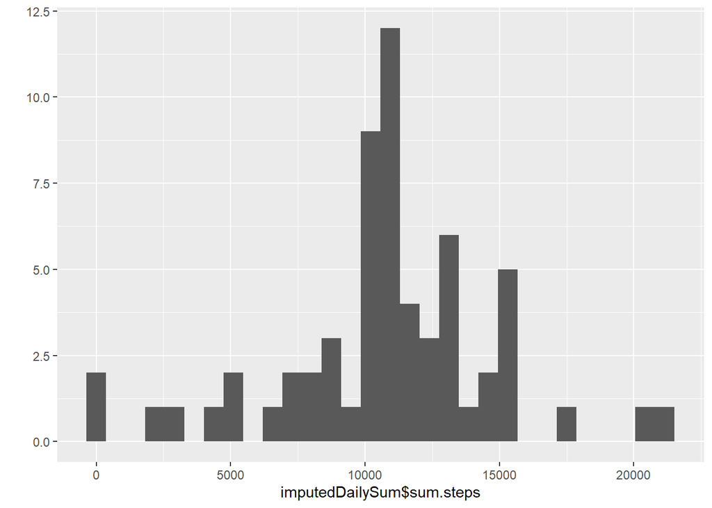

```r
qplot(imputedDailySum$sum.steps)
```

```r
imputedSummarizedByInterval <- group_by(imputedDataFile, interval)
imputedDailyInterval <- summarize(imputedSummarizedByInterval, ave.steps = mean(steps,na.rm = T))
imputed.daily.mean <- mean(imputedDailyInterval$ave.steps,na.rm = TRUE)
imputed.daily.median <- median(imputedDailyInterval$ave.steps,na.rm = TRUE)
```

## Differences in activity patterns between weekdays and weekends?

Here we plot the differences in activity patterns, modeled after the example.

```r
imputedDataFile$day <- weekdays(imputedDataFile$date)

imputedDataFile$day.category <- "Weekday"
for (i in 1:nrow(imputedDataFile)) {
  if (imputedDataFile$day[i] == "Saturday" | imputedDataFile$day[i] == "Sunday")
    imputedDataFile$day.category[i] <- "Weekend"
}
imputedDataFile$day.category <- as.factor(imputedDataFile$day.category)
imputedSummarizedByIntervalAndDay <- group_by(imputedDataFile, interval, day.category)
imputedDailyIntervalDay <- summarize(imputedSummarizedByIntervalAndDay, ave.steps = mean(steps,na.rm = T))
```

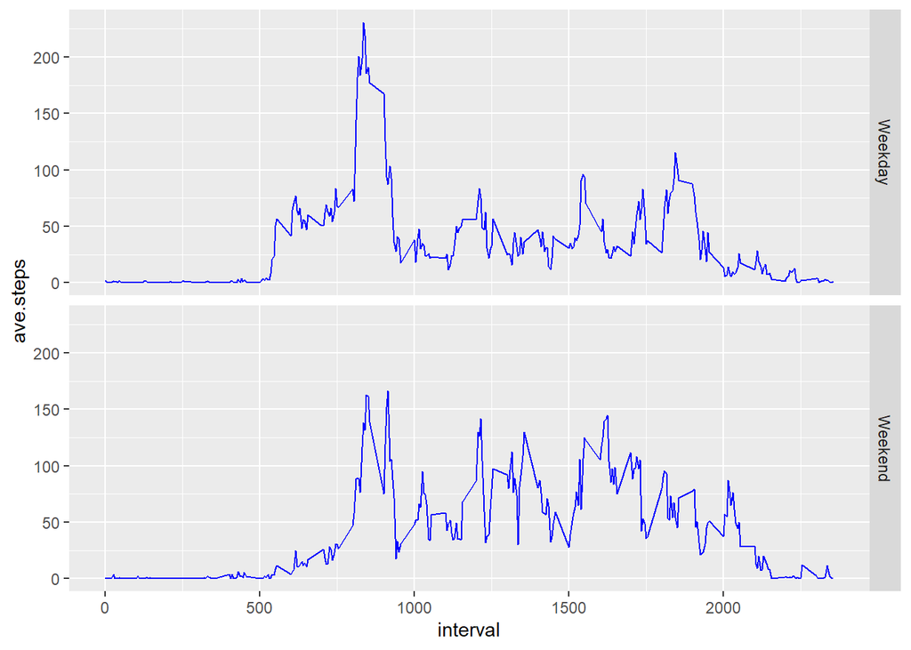

```r
WeeknamePlot <- ggplot(imputedDailyIntervalDay, aes(interval,ave.steps)) + geom_line(color="blue") + facet_grid(rows = vars(day.category))
print(WeeknamePlot)
```